# Monte Carlo Simulation of the 2D XY Model

## Fortran implementation with f2py interface

```python
!rm -f xy_fortran*.so xy_fortran*.pyd

!python -m numpy.f2py -c xy_fortran.f90 -m xy_fortran

from xy_fortran import xy_model
```

[output not shown]

[output cut: 131 more lines]

[output not shown]

Tutta la dinamica Monte Carlo è implementata in Fortran e richiamata via f2py. In questo notebook ci si limita ad organizzare le simulazioni ed analizzare i dati.

## Parametri del modello

Il modello XY è un modello classico di spin bidimensionale in cui ogni spin $\mathbf{s}_i$ è un vettore unitario che può ruotare liberamente sul piano:

$$ \mathbf{s}_i = (\cos \theta_i, \sin \theta_i), \quad \theta_i \in [0, 2\pi) $$

L'energia del sistema è data dall'Hamiltoniana:

$$ E = - \sum_{\langle i,j \rangle} \cos(\theta_i - \theta_j) $$

dove la somma $\langle i,j \rangle$ è estesa ai vicini più prossimi su una griglia quadrata di lato $L$.

I principali parametri del modello implementato nel modulo Fortran sono:

- **Dimensione della griglia $L$**: definisce un reticolo quadrato $L \times L$ di spin.
- **Temperatura $T$**: controlla l'intensità delle fluttuazioni termiche; è collegata al parametro $\beta = 1/T$ nelle funzioni di Boltzmann.
- **Configurazione iniziale**: può essere \emph{random} (angoli casuali tra $0$ e $2\pi$) o \emph{cold} (tutti gli spin allineati).
- **Delta ($\delta$)**: ampiezza massima della variazione di un angolo durante un passo di Metropolis.
- **Numero di sweep per equilibrazione e misura**: $n_\text{equil}$ e $n_\text{meas}$ determinano quanto a lungo il sistema viene evoluto prima di raccogliere statistiche.
- **Misure osservabili**: magnetizzazione $M$, energia $E$, vortici, correlazioni $\langle \theta^2 \rangle$, capacità termica $C_v$ e suscettibilità $\chi$.
- **Seed casuale**: parametro per inizializzare il generatore di numeri casuali, utile per riproducibilità.

Il modulo implementa inoltre algoritmi per:

- Calcolo dell'energia e della magnetizzazione totale.
- Aggiornamenti di Metropolis con tabella di Boltzmann precalcolata.
- Identificazione dei vortici topologici.
- Studio della correlazione angolare e della varianza $\langle \theta^2 \rangle$.
- Analisi statistica tramite binning e bootstrap per stimare gli errori.

Questi parametri consentono di studiare fenomeni come la transizione di Kosterlitz-Thouless, la formazione di vortici e l'evoluzione delle correlazioni in funzione della temperatura e della dimensione del sistema.

#### Unità di misura: ($J=1, k_B=1$)

- $[T] = J / k_B \quad \text{(adimensionale, scala numerica)}$
- $[E] = J \quad \text{(energia totale)}$
- $[C_v] = k_B^2 \quad \text{(calore specifico per spin, adimensionale)}$
- $[M] = 1 \quad \text{(magnetizzazione per spin, 0 ≤ M ≤ 1)}$
- $[\chi] = 1 \quad \text{(suscettività magnetica, adimensionale)}$
- $[\rho_v] = 1 \quad \text{(densità di vortici per plaquette, adimensionale)}$
- $[\theta] = \text{rad} \quad \text{(angolo degli spin)}$
- $[\delta] = \text{rad} \quad \text{(intervallo di aggiornamento angolare)}$
- $[\text{accept rate}] = 1 \quad \text{(frazione, adimensionale)}$

```python
import numpy as np
import matplotlib.pyplot as plt
```

```python
xy_model.set_random_seed(12345)
```

## 0. Time series of observables vs Monte Carlo sweeps

```python
L = 30
T = 0.1
beta = 1.0 / T
delta0 = 1.0

n_equil = 0
n_meas  = 1000
```

```python
theta = xy_model.init_random_config(L)
delta, acc = xy_model.run_equilibration(L, theta, beta, delta0, n_equil, 0.4)
```

```python
E, M, M2, theta2, vort, E2 = xy_model.run_measurement(L, theta, beta, delta, n_meas)
```

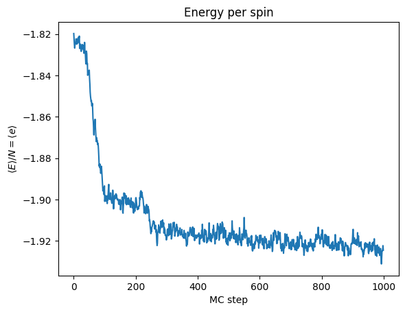

```python
plt.plot(E)
plt.xlabel("MC step")
plt.ylabel(r'$\langle E \rangle / N = \langle e \rangle$')
plt.title("Energy per spin")
plt.show()
```

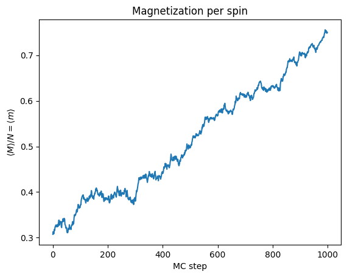

```python
plt.plot(M)
plt.xlabel("MC step")
plt.ylabel(r'$\langle M \rangle / N = \langle m \rangle$')
plt.title("Magnetization per spin")
plt.show()
```

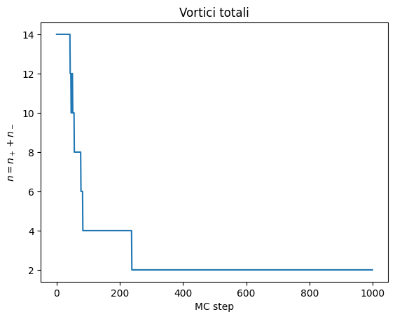

```python
plt.plot(vort)
plt.xlabel("MC step")
plt.ylabel('$n=n_++n_-$')
plt.title("Vortici totali")
plt.show()
```

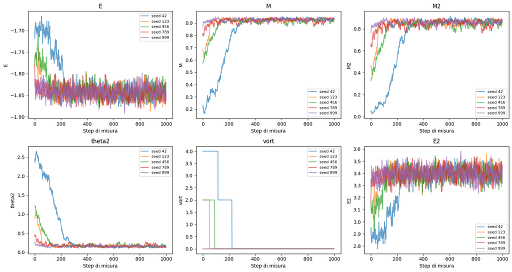

```python
import numpy as np
import matplotlib.pyplot as plt
L = 16
T = 0.3
beta = 1.0 / T
delta0 = 2.0

n_equil = 0
n_meas  = 1000

seeds = [42, 123, 456, 789, 999]

results = { 'E':[], 'M':[], 'M2':[], 'theta2':[], 'vort':[], 'E2':[] }

for seed in seeds:
    xy_model.set_random_seed(seed)
    theta = xy_model.init_random_config(L)

    # Equilibrazione (qui n_equil=0)
    delta, acc = xy_model.run_equilibration(L, theta, beta, delta0, n_equil, 0.4)

    E, M, M2, theta2, vort, E2 = xy_model.run_measurement(L, theta, beta, delta, n_meas)

    results['E'].append(E)
    results['M'].append(M)
    results['M2'].append(M2)
    results['theta2'].append(theta2)
    results['vort'].append(vort)
    results['E2'].append(E2)

quantities = ['E', 'M', 'M2', 'theta2', 'vort', 'E2']

fig, axes = plt.subplots(2, 3, figsize=(15, 8))
axes = axes.flatten()

for ax, q in zip(axes, quantities):
    for i, seed in enumerate(seeds):
        ax.plot(results[q][i], label=f'seed {seed}', alpha=0.7)
    ax.set_title(q)
    ax.set_xlabel('Step di misura')
    ax.set_ylabel(q)
    ax.legend(fontsize=8)

plt.tight_layout()
plt.show()
```

Per ogni grandezza usata nelle simulazioni e per ogni seme si è eseguita questa analisi preliminare per controllare a quale MC step corrisponde l'equilibrazione. Di seguito i risultati.

$T=0.3$:

$L=4$: nequil = 0; $L=8$: nequil = 100; $L=16$ nequil = 400 (* problema con seed 42 per $\delta_0=1.0$); $L=32$: nequil = 5000; $L=64$ nequil = 15000.

...

$T=0.6$:

$L=4$: nequil = 0; $L=8$: nequil = 500; $L=16$ nequil = 2000; $L=32$: nequil = 10000; $L=64$ nequil = 20000.

...

$T=0.9$:

$L=4$: nequil = 5000; $L=8$: nequil = 25000; $L=16$ nequil = 25000; $L=32$: nequil = 40000; $L=64$ nequil = 50000.

...

$T=1.3$:

$L=4$: nequil = 200; $L=8$: nequil = 300; $L=16$ nequil = 300; $L=32$: nequil = 5000; $L=64$ nequil = 10000.

...

$T=1.5$:

$L=4$: nequil = 100; $L=8$: nequil = 200; $L=16$ nequil = 100; $L=32$: nequil = 5000; $L=64$ nequil = 10000.

## 0.1 Autocorrelation functions

```python
max_lag = 500
C_E = xy_model.autocorrelation(len(E), E, max_lag)
C_M = xy_model.autocorrelation(len(M), M, max_lag)
```

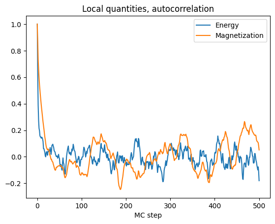

```python
plt.plot(C_E, label="Energy")
plt.plot(C_M, label="Magnetization")
plt.title("Local quantities, autocorrelation")
plt.xlabel("MC step")
plt.legend()
plt.show()
```

## 1. Scaling of ⟨θ²⟩ vs ln N at T = 0.1

Discutiamo l'ordine nel nostro sistema. All'interno dell'approssimazione spin-wave, esiste un'espressione esatta per $\langle \theta^2 \rangle$, analoga allo spostamento quadratico medio delle particelle utilizzato nella discussione dell'ordine nei cristalli. In qualsiasi sistema, $\langle \theta^2 \rangle$ diverge se $\theta$ è misurato rispetto a un asse fisso, poiché una rotazione uniforme non costa energia. Perciò definiamo $\theta_i$ come l'angolo rispetto alla direzione del momento totale istantaneo dello spin.

Consideriamo la funzione di Green

$$ G(\vec{n}) = - \frac{1}{N}\sum_{\mathbf{k}} \frac{e^{i\vec{k}\cdot\vec{n}}}{4 - 2 \cos(k_x) - 2 \cos(k_y)}. $$

Se si approssima $G(n)$ tramite un integrale, si trova esplicitamente:

$$ \langle \theta^2 \rangle =\frac{T}{4\pi}\left(\ln N + \ln 2\right). $$

```python
L_values = np.array([4, 8, 16, 24, 32, 64], dtype=np.int32)
n_L = len(L_values)

xy_model.set_random_seed(999)

T = 0.1
n_equil = 15000
n_meas = 5000

theta2_mean, theta2_err, delta_out, acc_out = xy_model.study_theta2_vs_n(n_L, L_values, T, n_equil, n_meas)
```

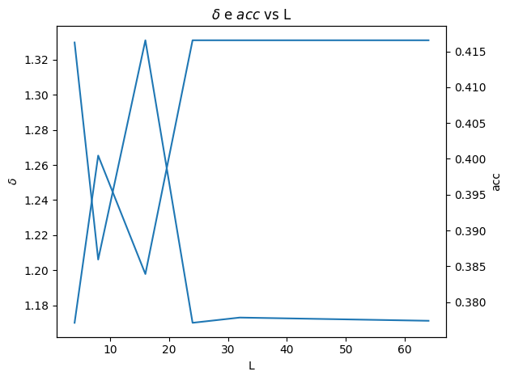

```python
fig, ax1 = plt.subplots()

# Primo asse y: delta_out
ax1.plot(L_values, delta_out)
ax1.set_xlabel("L")
ax1.set_ylabel("$\delta$")
ax1.tick_params(axis='y')

# Secondo asse y: acc_out
ax2 = ax1.twinx()
ax2.plot(L_values, acc_out)
ax2.set_ylabel("acc")
ax2.tick_params(axis='y')

plt.title("$\delta$ e $acc$ vs L")
plt.tight_layout()
plt.show()
```

```
Fit: a = 0.00824 ± 0.00003, b = 0.00461 ± 0.00019
```

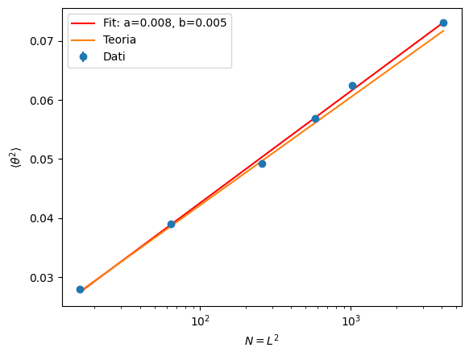

```python
import numpy as np
import matplotlib.pyplot as plt
from scipy.optimize import curve_fit

N = L_values**2
theta2_theory = T/(4*np.pi)*(np.log(N)+np.log(2))
y = theta2_mean
yerr = theta2_err

# Funzione di fit lineare: theta2 = a*ln(N) + b
def linear_fit(x, a, b):
    return a * np.log(x) + b

popt, pcov = curve_fit(linear_fit, N, y, sigma=yerr, absolute_sigma=True)
a_fit, b_fit = popt
a_err, b_err = np.sqrt(np.diag(pcov))

print(f"Fit: a = {a_fit:.5f} ± {a_err:.5f}, b = {b_fit:.5f} ± {b_err:.5f}")

# Plot
plt.errorbar(N, y, yerr=yerr, fmt='o', label='Dati')
plt.plot(N, linear_fit(N, *popt), 'r-', label=f'Fit: a={a_fit:.3f}, b={b_fit:.3f}')
plt.plot(N, theta2_theory, label="Teoria")
plt.xscale('log')
plt.xlabel(r"$N=L^2$")
plt.ylabel(r"$\langle \theta^2 \rangle$")
plt.legend()
plt.show()
```

Ora, mediando sui 5 seed:

```python
import numpy as np

L_values = np.array([4, 8, 16, 24, 32, 64], dtype=np.int32)
n_L = len(L_values)
seeds = [42, 123, 456, 789, 999]

theta2_all = np.zeros((len(seeds), n_L))

T = 0.1
n_equil = 20000
n_meas = 5000

for i, seed in enumerate(seeds):
    xy_model.set_random_seed(seed)

    theta2_mean, theta2_err, delta_out, acc_out = xy_model.study_theta2_vs_n(
        n_L, L_values, T, n_equil, n_meas
    )

    theta2_all[i, :] = theta2_mean

theta2_mean_over_seeds = np.mean(theta2_all, axis=0)
theta2_std_over_seeds = np.std(theta2_all, axis=0, ddof=1)
```

```
Fit: a = 0.00777 ± 0.00010 rad², b = 0.00639 ± 0.00041 rad²
```

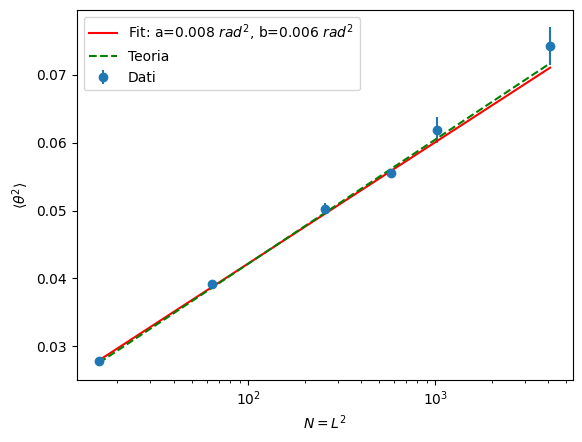

```python
N = L_values**2
y = theta2_mean_over_seeds
yerr = theta2_std_over_seeds

# Funzione di fit lineare: theta2 = a*ln(N) + b
def linear_fit(x, a, b):
    return a * np.log(x) + b

popt, pcov = curve_fit(linear_fit, N, y, sigma=yerr, absolute_sigma=True)
a_fit, b_fit = popt
a_err, b_err = np.sqrt(np.diag(pcov))

print(f"Fit: a = {a_fit:.5f} ± {a_err:.5f} rad², b = {b_fit:.5f} ± {b_err:.5f} rad²")

plt.errorbar(N, y, yerr=yerr, fmt='o', label='Dati')
plt.plot(N, linear_fit(N, *popt), 'r-', label=f'Fit: a={a_fit:.3f} $rad^2$, b={b_fit:.3f} $rad^2$')
plt.plot(N, theta2_theory, 'g--', label='Teoria')
plt.xscale('log')
plt.xlabel(r"$N=L^2$")
plt.ylabel(r"$\langle \theta^2 \rangle$")
plt.legend()
plt.show()
```

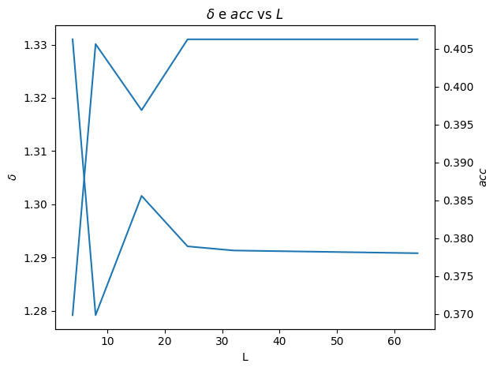

```python
fig, ax1 = plt.subplots()

# Primo asse y: delta_out
ax1.plot(L_values, delta_out)
ax1.set_xlabel("L")
ax1.set_ylabel("$\delta$")
ax1.tick_params(axis='y')

# Secondo asse y: acc_out
ax2 = ax1.twinx()
ax2.plot(L_values, acc_out)
ax2.set_ylabel("$acc$")
ax2.tick_params(axis='y')

plt.title("$\delta$ e $acc$ vs $L$")
plt.tight_layout()
plt.show()
```

Nell'articolo di Tobochnik e Chester risultava $0.00786 \pm 0.00016$ per la pendenza e $0.00603\pm 0.00104$ per l'intercetta. In ottimo accordo con gli errori. DOI: https://doi.org/10.1103/PhysRevB.20.3761.

## 2. Angular differences and topological charge

Nel modello XY bidimensionale, ogni spin è rappresentato da un angolo $\theta_i \in [0, 2\pi)$. Quando si calcolano le differenze angolari tra spin vicini, è fondamentale ricondurle nell'intervallo

$$ \Delta \theta = \theta_j - \theta_i, \quad -\pi < \Delta \theta < \pi $$

Questa riduzione garantisce:

1. La **rotazione totale intorno a una plaquette** (un quadrato di 4 spin) è un multiplo intero di $2\pi$.
2. La **carica topologica dei vortici** è ben definita, cioè possiamo contare correttamente vortici positivi e negativi.

**1. Su Fortran l'aggiornamento Metropolis (subroutine `metropolis_sweep`, line 139) è scritto come**

```
theta_new = theta_old + delta * (rnd - 0.5d0)
```

**2. Ricondizionamento delle differenze angolari per i vortici (subroutine `find_vortices`, line 250) è scritto come**

```
delta_theta = angles(i+1) - angles(i)
do while (delta_theta > PI)
    delta_theta = delta_theta - TWO_PI
end do
do while (delta_theta < -PI)
    delta_theta = delta_theta + TWO_PI
end do
total_rotation = total_rotation + delta_theta
```

## 3. Temperature quench and metastable vortices

```python
Lq = 32
theta_q = np.zeros((Lq, Lq), order='F')
T_final = 0.5
n_sweeps = 100

theta, n_pos, n_neg, delta_out, accept_out = xy_model.temperature_quench(Lq, T_final, n_sweeps)
```

```python
print("Positive vortices:", n_pos)
print("Negative vortices:", n_neg)
```

```
Positive vortices: 1
Negative vortices: 1
```

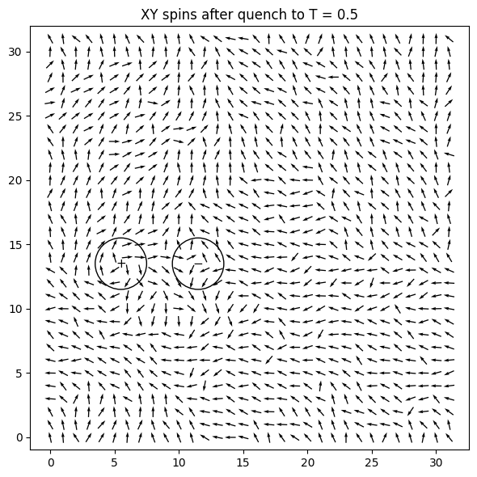

```python
from matplotlib.pyplot import Circle
L = Lq

# coordinate del reticolo
x = np.arange(L)
y = np.arange(L)
X, Y = np.meshgrid(x, y, indexing='ij')

# componenti degli spin
Ux = np.cos(theta)
Uy = np.sin(theta)

plt.figure(figsize=(6, 6))
plt.quiver(X, Y, Ux, Uy, pivot='middle', scale=40)
plt.title(f"XY spins after quench to T = {T_final}")
plt.axis('equal')
# plt.xlim(0, L)
# plt.ylim(0, L)
plt.tight_layout()

# Calcolo vorticità
vorticity = np.zeros((L, L), dtype=np.int32, order='F')
xy_model.compute_vorticity(theta, vorticity)

# Plot
radius_circle = 2.0

for i in range(L):
    for j in range(L):
        q = vorticity[j, i]
        if q != 0:
            # centro del vortice (plaquette)
            cx, cy = j + 0.5, i + 0.5

            plt.gca().add_patch(
                Circle(
                    (cx, cy),
                    radius = radius_circle,
                    edgecolor='black',
                    fill=False,
                    linewidth=1.0   # più sottile
                )
            )

            plt.text(
                cx, cy,
                '+' if q > 0 else '−',
                color='black',
                fontsize=11,      # più piccolo
                ha='center',
                va='center',
                fontweight='normal'
            )
```

```python
L = Lq
T_final = 0.5
n_runs = 5
n_sweeps = 300
npos_list = []
nneg_list = []

for i in range(n_runs):
    for seed in seeds:
        xy_model.set_random_seed(seed)
        theta = xy_model.init_random_config(L)
        theta, n_pos, n_neg, delta_out, accept_out = xy_model.temperature_quench(Lq, T_final, n_sweeps)
        npos_list.append(n_pos)
        nneg_list.append(n_neg)

print("Positive vortices:", npos_list)
print("Negative vortices:", nneg_list)
print("Mean n_pos =", np.mean(npos_list))
print("Mean n_neg =", np.mean(nneg_list))
```

```
Positive vortices: [2, 0, 1, 1, 0, 2, 0, 1, 1, 0, 2, 0, 1, 1, 0, 2, 0, 1, 1, 0, 2, 0, 1, 1, 0]
Negative vortices: [2, 0, 1, 1, 0, 2, 0, 1, 1, 0, 2, 0, 1, 1, 0, 2, 0, 1, 1, 0, 2, 0, 1, 1, 0]
Mean n_pos = 0.8
Mean n_neg = 0.8
```

Dopo un quench di temperatura da $T=\infty$ a $T=0.5$, il sistema si congela in una configurazione metastabile che contiene vortici a lunga vita. L’ispezione visiva della configurazione degli spin mostra coppie vortice–antivortice bloccate nel reticolo. Ripetendo il quench per diverse condizioni iniziali casuali, si osserva che il numero di vortici positivi e negativi è approssimativamente uguale entro le fluttuazioni statistiche, in accordo con la conservazione della carica topologica totale.

## 4. Temperature scan: energy, $C_v$ and vorticity

Energia media per sito $$\varepsilon = \frac{E}{L^2} $$

$$\langle \varepsilon \rangle = \frac{1}{n_{\mathrm{meas}}} \sum_{k=1}^{n_{\mathrm{meas}}} \varepsilon_k. $$ Calore specifico per sito $$C_v = \frac{L^2}{T^2} \left( \langle \varepsilon^2 \rangle - \langle \varepsilon \rangle^2 \right)$$

$$\langle \varepsilon^2 \rangle = \frac{1}{n_{\mathrm{meas}}} \sum_{k=1}^{n_{\mathrm{meas}}} \varepsilon_k^2 $$ Densità di vortici $$\rho_v = \frac{n_v}{L^2} $$ $$\langle \rho_v \rangle = \frac{1}{n_{\mathrm{meas}}} \sum_{k=1}^{n_{\mathrm{meas}}} \rho_{v,k} $$

```python
# Qui, si è mantenuta 1 esecuzione di temperature_scan_2 solo per velocità di visualizzazioe. Si è mediato su 5 seed per i dati finali.
```

```python
L = 64
T_vals = np.arange(0.5, 1.7, 0.1)
n_T = len(T_vals)

n_equil = 5000
n_meas = 10000

(E_m, E_err_bin, E_err_boot, M_m, M_err_bin, M_err_boot, M2_m, Chi_vals, Cv_heat, V_m, V_err_bin, V_err_boot,
 theta_final, acc_rates, deltas) = xy_model.temperature_scan_2(L, n_T, T_vals, n_equil, n_meas)
```

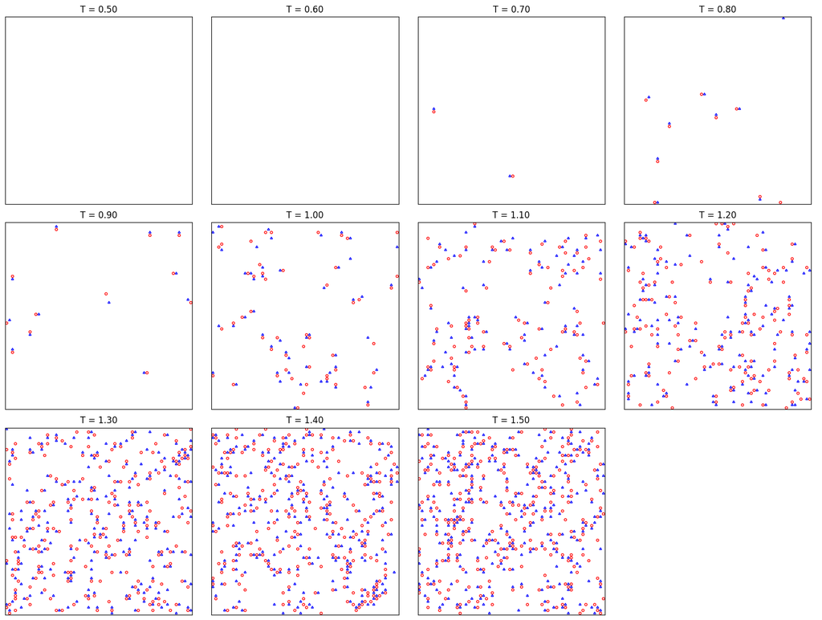

```python
from matplotlib.patches import Circle, RegularPolygon
import matplotlib.pyplot as plt
import numpy as np

T_vals = np.arange(0.5, 1.6, 0.1)
n_T = len(T_vals)  # 11 temperature

fig, axes = plt.subplots(3, 4, figsize=(16, 12))
axes = axes.flatten()

for idx, ax in enumerate(axes):
    if idx >= n_T:
        ax.axis('off')
        continue

    theta = theta_final[:, :, idx]  # configurazione alla temperatura T_vals[idx]
    T = T_vals[idx]

    # Calcolo vorticità
    vorticity = np.zeros((L, L), dtype=np.int32, order='F')
    xy_model.compute_vorticity(theta, vorticity)

    # Disegna vortici
    for i in range(L):
        for j in range(L):
            q = vorticity[i, j]
            if q != 0:
                # centro del vortice
                cx, cy = j, i

                if q == 1:
                    ax.add_patch(
                        Circle((cx, cy), radius=0.4, edgecolor='red', fill=False, linewidth=1.0)
                    )
                elif q == -1:
                    ax.add_patch(
                        RegularPolygon(
                            (cx, cy), numVertices=3, radius=0.45, orientation=0,
                            edgecolor='blue', fill=False, linewidth=1.0
                        )
                    )

    # Imposta aspetto e limiti
    ax.set_aspect('equal')
    ax.set_xlim(-0.5, L - 0.5)
    ax.set_ylim(-0.5, L - 0.5)
    ax.set_xticks([])
    ax.set_yticks([])
    ax.set_title(f"T = {T:.2f}")

plt.tight_layout()
plt.show()
```

Nel modello XY 2D, i vortici sono difetti topologici in cui gli spin ruotano di $2\pi$ attorno a un plaquette. Si distinguono:

- **Vortici positivi ($+1$):** rotazione antioraria
- **Vortici negativi ($-1$):** rotazione oraria

A basse temperature ($T \ll T_{KT}$), i vortici compaiono in coppie legate ($+1, -1$). Il costo energetico per avere un vortice libero è troppo alto, quindi i vortici liberi sono praticamente assenti. All’aumentare della temperatura a $T \sim T_{KT} \approx 0.89$ (per il modello XY 2D), queste coppie iniziano a dissociarsi e compaiono vortici liberi. A temperature $T > T_{KT}$, la maggior parte dei vortici è libera e il sistema risulta disordinato.

Si faccia riferimento alla Figura 7 del paper. In triangolo blu, vortici negativi, in rosso, cerchio, quelli positivi.

#### 4.1 Densità di vortici

Fit Arrhenius della densità di vortici $$\rho_v(T) \sim \exp\Big(-\frac{E_c}{T}\Big) \quad \quad \quad \ln \rho_v(T) = \ln A - \frac{E_c}{T} $$ Versione generale con prefattore e offset $$\rho_v(T) = A \, \exp\Big(-\frac{E_c}{T}\Big) + \rho_0 $$ dove:

- $E_c$ è l'energia di creazione di un vortice,
- $A$ è un prefattore moltiplicativo,
- $\rho_0$ è un eventuale contributo residuo,
- $T$ è la temperatura,
- $\rho_v(T)$ è la densità media di vortici.

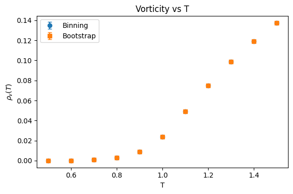

```python
plt.figure(figsize=(6,4))
plt.errorbar(T_vals, V_m[:-1], yerr=V_err_bin[:-1], fmt='o', label='Binning', capsize=3)
plt.errorbar(T_vals, V_m[:-1], yerr=V_err_boot[:-1], fmt='s', label='Bootstrap', capsize=3)
plt.xlabel('T')
plt.ylabel(r'$\rho_v(T)$')
plt.title('Vorticity vs T')
plt.legend()
plt.tight_layout()
plt.show()
```

```
Fit parameters:
A   = 53 ± 2
E_c = 7.76 ± 0.04
V0  = 0.000007 ± 0.000001
```

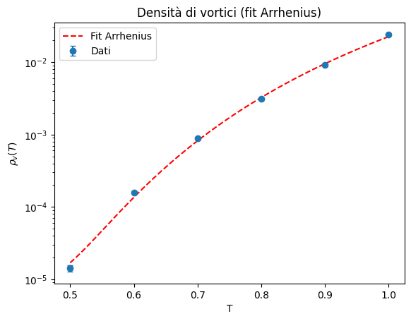

```python
# Funzione Arrhenius
def arrhenius(T, A, E_c, V0):
    return A * np.exp(-E_c / T) + V0

# Fit (solo T < 1.1)
T_fit = T_vals[:-5]
V_fit = V_m[:-6]
V_err = V_err_bin[:-6]

popt, pcov = curve_fit(arrhenius, T_fit, V_fit, sigma=V_err,
                       absolute_sigma=True, p0=[0.5, 1.0, 0.0])

A, E_c, V0 = popt
perr = np.sqrt(np.diag(pcov))

print(f"Fit parameters:")
print(f"A   = {A:.0f} ± {perr[0]:.0f}")
print(f"E_c = {E_c:.2f} ± {perr[1]:.2f}")
print(f"V0  = {V0:.6f} ± {perr[2]:.6f}")

# Curve liscia
T_smooth = np.linspace(T_fit.min(), T_fit.max(), 200)
V_smooth = arrhenius(T_smooth, *popt)

# --- Plot logaritmico ---
plt.errorbar(T_fit, V_fit, yerr=V_err, fmt='o', capsize=3, label='Dati')
plt.plot(T_smooth, V_smooth, 'r--', label='Fit Arrhenius')
plt.xlabel("T")
plt.ylabel(r"$\rho_v(T)$")
plt.title("Densità di vortici (fit Arrhenius)")
plt.yscale('log')  # scala logaritmica sull'asse y
plt.legend()
plt.show()
```

#### 4.2 Energia media per spin

A basse temperature $$\langle \varepsilon \rangle(T) = \frac{\langle E \rangle}{N} \approx -2 + \frac{T}{2} $$ dove:

- $\langle E \rangle$ è l'energia totale della rete,
- $N = L^2$ è il numero totale di spin,
- $T$ è la temperatura (adimensionale, $k_B=1$),
- il termine $-2$ corrisponde all'energia a $T=0$ per una rete quadrata 2D con $z=4$ vicini,
- il termine $T/2$ proviene dalle fluttuazioni termiche (spin-wave) a basse temperature.

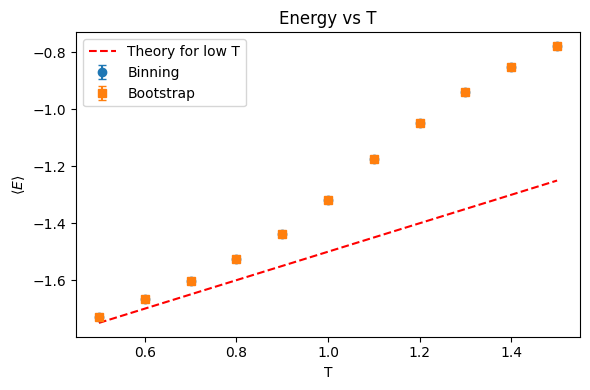

```python
plt.figure(figsize=(6,4))
plt.xlabel("T")
plt.ylabel(r"$\langle E \rangle$")
E_theo_lowT=T_vals*0.5-2.
plt.plot(T_vals, E_theo_lowT, '--r', label="Theory for low T")
plt.errorbar(T_vals, E_m[:-1], yerr=E_err_bin[:-1], fmt='o', label='Binning', capsize=3)
plt.errorbar(T_vals, E_m[:-1], yerr=E_err_boot[:-1], fmt='s', label='Bootstrap', capsize=3)
plt.title('Energy vs T')
plt.legend()
plt.tight_layout()
plt.show()
```

#### 4.3 Calore specifico

Si è deciso di analizzare il calore specifico riscaldando e raffreddando poiché la derivata dà esiti diversi.

```python
T_vals = np.arange(1.6, 0.5, -0.1)
n_T = len(T_vals)

(E_m, E_err_bin, E_err_boot, M_m, M_err_bin, M_err_boot, M2_m, Chi_vals_cooling, Cv_cool, V_m, V_err_bin, V_err_boot,
 theta_final, acc_rates, deltas) = xy_model.temperature_scan_2(L, n_T, T_vals, n_equil, n_meas)
```

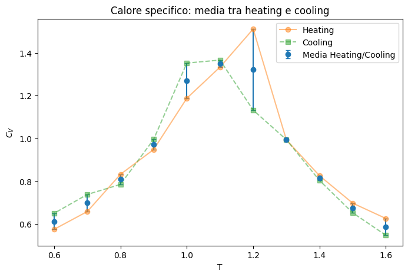

```python
Cv_mean = 0.5*(Cv_heat[1:] + Cv_cool)
Cv_err = 0.5*np.abs(Cv_heat[1:] - Cv_cool)

# Plot
plt.figure(figsize=(8,5))
plt.errorbar(T_vals, Cv_mean, yerr=Cv_err, fmt='o', capsize=3, label="Media Heating/Cooling")
plt.plot(T_vals, Cv_heat[1:], 'o-', alpha=0.5, label="Heating")
plt.plot(T_vals, Cv_cool, 's--', alpha=0.5, label="Cooling")
plt.xlabel("T")
plt.ylabel(r"$C_V$")
plt.title("Calore specifico: media tra heating e cooling")
plt.legend()
plt.show()
```

## 6. Kosterlitz–Thouless susceptibility fit

Abbiamo stimato la temperatura critica $T_{KT}$ del modello XY 2D usando la suscettibilità $\chi(T)$ e la relazione prevista vicino alla transizione:

$$ \chi(T) \sim A \, \exp\Big( b / \epsilon^\nu \Big), \quad \epsilon = \frac{T - T_{KT}}{T_{KT}} $$

dove $A$ e $b$ sono parametri del fit e $\nu = 0.7$ è l’esponente critico.

- Si scandiscono possibili valori di $T_{KT}$ in un intervallo $[T_{\rm min}, T_{\rm max}]$.
- Per ogni candidato $T_{KT}$, si selezionano i dati con $T > T_{KT}$ e $\epsilon > 0.01$.
- Si esegue un fit lineare $$ \ln \chi = \ln A + b \cdot \frac{1}{\epsilon^\nu}. $$
- Si calcola la varianza dei residui $$ \sigma^2 = \frac{1}{N-2} \sum_i \big( \ln \chi_i - \ln \chi_i^{\rm pred} \big)^2 $$ e si salva il set di parametri con varianza minima.
- Gli errori sui parametri si stimano come: $$ \sigma_b = \sqrt{\frac{\sigma^2}{\sum_i (x_i - \bar{x})^2}}, \quad \sigma_{\rm intercept} = \sqrt{ \sigma^2 \frac{\sum_i x_i^2}{N \sum_i (x_i - \bar{x})^2} }, \quad \sigma_A = A \, \sigma_{\rm intercept}. $$

Si generano dati vicini all'intervallo richiesto.

```python
T_min = 1.0
T_max = 1.2
nu = 0.7
n_trials = 200
T_vals = np.arange(1.0, 1.25, 0.05)
n_T = len(T_vals)
n_equil = 1000
n_meas = 10000

(E_m, E_err_bin, E_err_boot, M_m, M_err_bin, M_err_boot, M2_m, Chi_vals_fit, Cv_cool, V_m, V_err_bin, V_err_boot,\
 theta_final, acc_rates, deltas) = xy_model.temperature_scan_2(L, n_T, T_vals, n_equil, n_meas)
```

```python
Chi_vals = Chi_vals_fit
err_chi = M_err_boot
```

```python
TKT, A, b , sigma_a, sigma_b, var= xy_model.fit_kt_transition(n_T, T_vals, Chi_vals_fit, T_min, T_max, nu, n_trials)
```

```python
print(f"Fit della transizione KT:")
print(f"T_K_T = {TKT:.2f}")
print(f"A     = {A:.2f} ± {sigma_a:.2f}")
print(f"b     = {b:.1f} ± {sigma_b:.1f}")
print(f"Varianza residui = {var:.3f}")
```

```
Fit della transizione KT:
T_K_T = 1.00
A     = 18.04 ± 0.14
b     = 0.4 ± 0.0
Varianza residui = 0.000
```

Per migliorare la stima converrebbe aumentare nequil alla temperatura di transizione.

Il valore stimato di $T_{KT}$ è coerente con la temperatura alla quale compaiono vortici liberi, ma distinto dal massimo del calore specifico, in accordo con la teoria di Kosterlitz–Thouless.

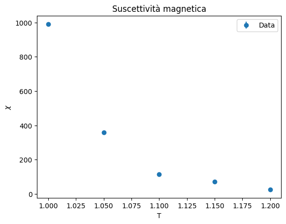

```python
plt.errorbar(T_vals, Chi_vals_fit, yerr=M_err_boot, fmt='o', label='Data')
plt.xlabel("T")
plt.ylabel(r"$\chi$")
plt.legend()
plt.title("Suscettività magnetica")
plt.show()
```

```python
nu = 0.7
mask = (T_vals > TKT) & (T_vals < 1.2)

epsilon = (T_vals[mask] - TKT) / TKT
x = 1.0 / (epsilon**nu)
y = np.log(Chi_vals_fit[mask])
```

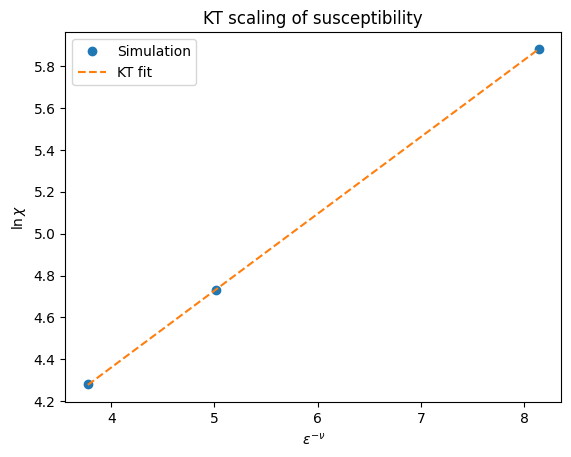

```python
plt.plot(x, y, 'o', label="Simulation")

# retta dal fit
xfit = np.linspace(min(x), max(x), 200)
yfit = np.log(A) + b * xfit
plt.plot(xfit, yfit, '--', label="KT fit")

plt.xlabel(r"$\epsilon^{-\nu}$")
plt.ylabel(r"$\ln \chi$")
plt.title("KT scaling of susceptibility")
plt.legend()
plt.show()
```

## Fit con grandi prese dati

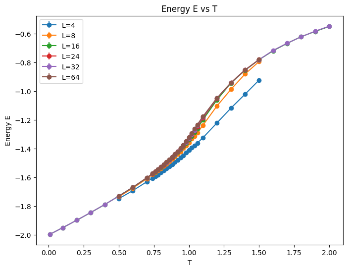

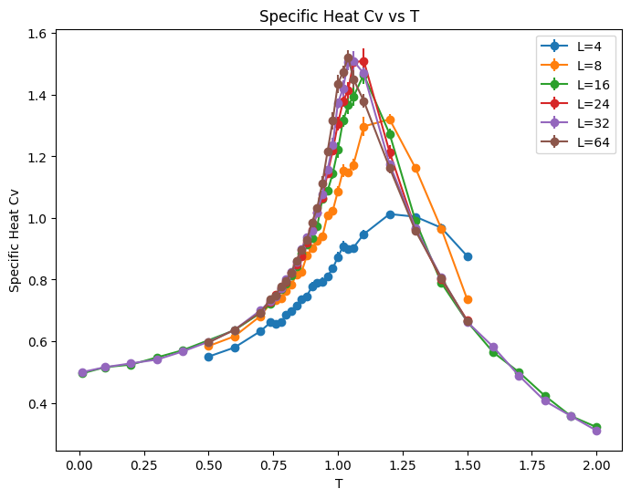

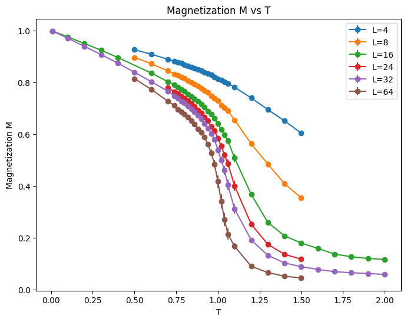

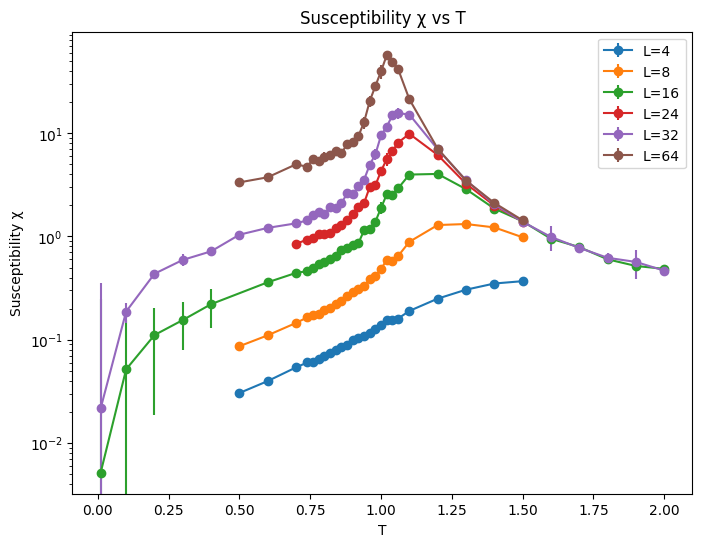

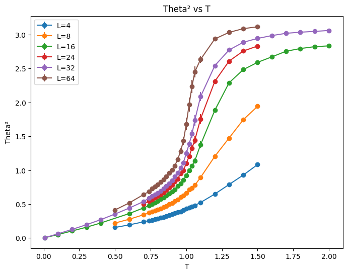

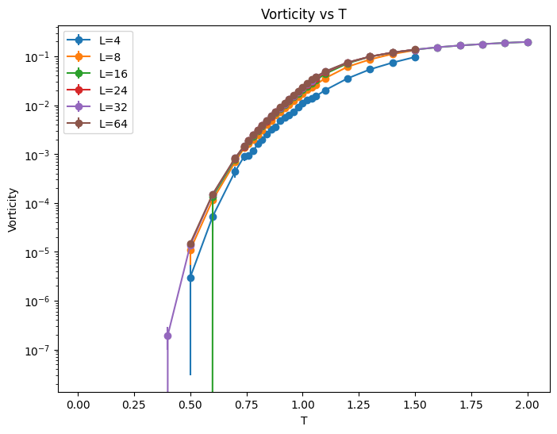

```python
import pandas as pd
import matplotlib.pyplot as plt
import numpy as np

L_list = [4, 8, 16, 24, 32, 64]

# Dizionario per contenere i dataframe
data = {}

# Colonne
cols = ['T','E','dE','Cv','dCv','M','dM','chi','dchi','theta2','dtheta2','vort','dvort']

# Caricamento dei file CSV
for L in L_list:
    filename = f"L{L}_data.csv"
    df = pd.read_csv(filename, sep=',', engine='python', header=None, names=cols)

    # Rimuove eventuali spazi iniziali/finali e converte in numerico
    df = df.apply(lambda x: pd.to_numeric(x.astype(str).str.strip(), errors='coerce'))

    data[L] = df

# Funzione per plottare con errorbar
def plot_quantity(quantity, dquantity, ylabel):
    plt.figure(figsize=(8,6))
    for L in L_list:
        df = data[L]
        plt.errorbar(df['T'], df[quantity], yerr=df[dquantity],
                     marker='o', linestyle='-', label=f"L={L}")
    plt.xlabel("T")
    plt.ylabel(ylabel)
    plt.title(ylabel + " vs T")
    plt.legend()
    plt.show()

def plot_logquantity(quantity, dquantity, ylabel):
    plt.figure(figsize=(8,6))
    for L in L_list:
        df = data[L]
        plt.errorbar(df['T'], df[quantity], yerr=df[dquantity],
                     marker='o', linestyle='-', label=f"L={L}")
    plt.xlabel("T")
    plt.ylabel(ylabel)
    plt.yscale('log')
    plt.title(ylabel + " vs T")
    plt.legend()
    plt.show()

plot_quantity('E','dE','Energy E')
plot_quantity('Cv','dCv','Specific Heat Cv')
plot_quantity('M','dM','Magnetization M')
plot_logquantity('chi','dchi','Susceptibility χ')
plot_quantity('theta2','dtheta2','Theta²')
plot_logquantity('vort','dvort','Vorticity')
```